# Index

# 80 anos ou mais

### Nesta faixa de idade têm-se 250.630 pessoas. Até a semana epidemiológica 23, segundo dados obtidos do [Ministério da Saúde](https://opendatasus.saude.gov.br/dataset/covid-19-vacinacao), foram vacinadas 245.948 pessoas com a 1ª dose e 216.999 pessoas com a 2ª dose no estado do Paraná.

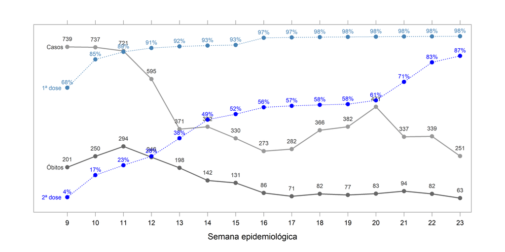

# 70 a 79 anos

### Nesta faixa de idade têm-se 537.275 pessoas. Até a semana epidemiológica 23, segundo dados obtidos do [Ministério da Saúde](https://opendatasus.saude.gov.br/dataset/covid-19-vacinacao), foram vacinadas 551.679 pessoas com a 1ª dose e 506.043 pessoas com a 2ª dose no estado do Paraná.

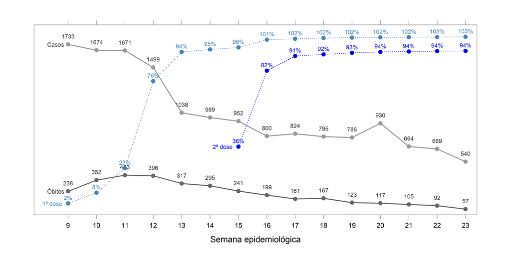

# 60 a 69 anos

### Nesta faixa de idade têm-se 993.908 pessoas. Até a semana epidemiológica23, segundo dados obtidos do [Ministério da Saúde](https://opendatasus.saude.gov.br/dataset/covid-19-vacinacao), foram vacinadas 983.952 pessoas com a 1ª dose e 255.628 pessoas com a 2ª dose no estado do Paraná.

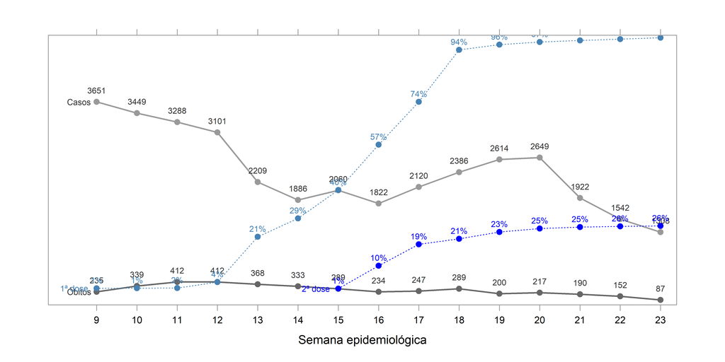

# Abaixo de 60 anos

### Nesta faixa de idade têm-se 2.298.197 pessoas (considerados apenas do grupo de risco). Até a semana epidemiológica 23, segundo dados obtidos do [Ministério da Saúde](https://opendatasus.saude.gov.br/dataset/covid-19-vacinacao), foram vacinadas 1.382.635 pessoas com a 1ª dose e 280.924 pessoas com a 2ª dose no estado do Paraná.

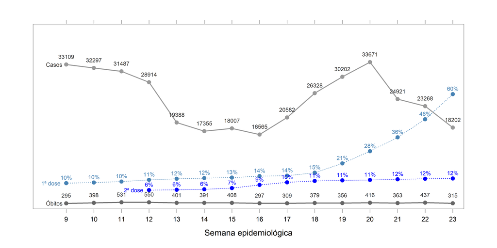

# Outros

### Variação de óbitos em relação à semana anterior

| Faixas de idade | Variação (%) |
| --- | --- |
| Acima de 80 anos | -23% |
| Entre 70 e 79 anos | -38% |
| Entre 60 e 69 anos | -43% |
| Menores de 60 anos | -28% |

## Column {data-width=800}

### Percentual de casos por semana epidemiológica

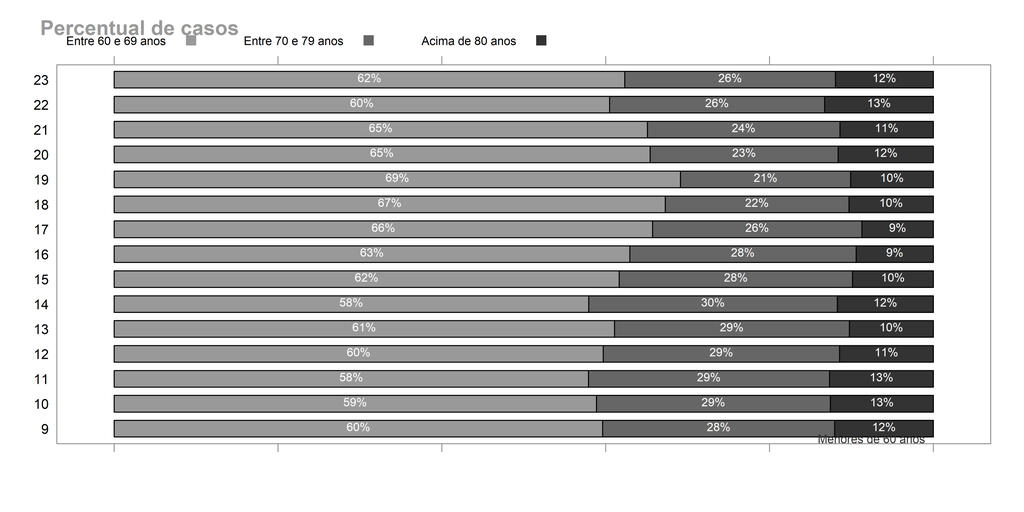

### Percentual de óbitos por semana epidemiológica

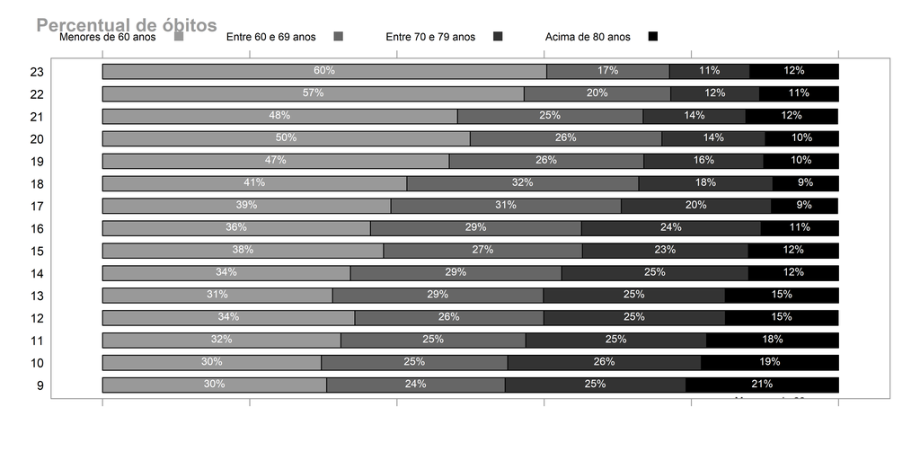